# odeintr

Uriah Daugaard

26 November, 2021

# 1 About

In this document I implement the ODEs used by Bush et al. (2017) using the package odeintr. I do this because (1) I’m pretty sure that this is the fastest way of solving ODEs in R and (2) this document can serve as a HOW-TO.

The difference to other approaches is that in ODEINTR the ODEs need to be compiled before they can be used. This takes about 10 seconds (usually, depending on the computer) up to max a minute. This times needs to be accounted when we compare approaches. However, they need to be compiled only once per R-session, so for each run after the first this time does not occur anymore. The running of the ODEs (i.e. solving them) should then be very very veeery fast!

Here I do the following:

- Implement the ODEs
- Reproduce Figure 2a,b of Bush et al 2017 and see how long it takes
- At some point compare with the implemented version in microxanox to see what is faster.

I’ve mentioned the possibility of using this package back in August: https://github.com/UZH-PEG/microxanox/issues/20

# 2 README

As of now, the two methods (ODEINTR and microxanox) produce different results (when I compare the two datasets at the end of this document). Hence, there is probably a mistake somewhere, so what is shown here should be further tested before any decision is made.

# 3 libraries

```r
library(odeintr)
library(tidyverse)
library(patchwork)
library(microbenchmark)
```

# 4 Implementing the ODES with ODEINTR

## 4.1 The ODEs (in C)

The ODEs like this don’t look that nice, but once they’re written no need to look at them again…

```r
ODEs = '
dxdt[0] = g_max_CB*(x[6]/(K_CB_P + x[6])) * 1/(1 + (x[4]/H_CB_S_R)) * x[0] - m_CB*x[0];
dxdt[1] = g_max_PB*(x[6]/(K_PB_P + x[6]))*(x[4]/(K_PB_S_R + x[4])) * 1/(1 + (x[5]/H_PB_O)) * x[1] - m_PB*x[1];
dxdt[2] = g_max_SB*(x[6]/(K_SB_P + x[6]))*(x[3]/(K_SB_S_O + x[3])) * 1/(1 + (x[5]/H_SB_O)) * x[2] - m_SB*x[2];
dxdt[3] = g_max_PB*(x[6]/(K_PB_P + x[6]))*(x[4]/(K_PB_S_R + x[4])) * 1/(1 + (x[5]/H_PB_O)) * x[1]/gamma_SR_PB - g_max_SB*(x[6]/(K_SB_P + x[6]))*(x[3]/(K_SB_S_O + x[3])) * 1/(1 + (x[5]/H_SB_O)) * x[2]/gamma_SO_SB + c*x[5]*x[4] + alpha_S*(S_O_b-x[3]);
dxdt[4] = - g_max_PB*(x[6]/(K_PB_P + x[6]))*(x[4]/(K_PB_S_R + x[4])) * 1/(1 + (x[5]/H_PB_O)) * x[1]/gamma_SR_PB + g_max_SB*(x[6]/(K_SB_P + x[6]))*(x[3]/(K_SB_S_O + x[3])) * 1/(1 + (x[5]/H_SB_O)) * x[2]/gamma_SO_SB - c*x[5]*x[4] + alpha_S*(S_R_b-x[4]);
dxdt[5] = p_CB * g_max_CB*(x[6]/(K_CB_P + x[6])) * 1/(1 + (x[4]/H_CB_S_R)) * x[0] - c*x[5]*x[4] + alpha_O*(O_b-x[5]);
dxdt[6] = - g_max_CB*(x[6]/(K_CB_P + x[6])) * 1/(1 + (x[4]/H_CB_S_R)) * x[0]/gamma_P_CB - g_max_PB*(x[6]/(K_PB_P + x[6]))*(x[4]/(K_PB_S_R + x[4])) * 1/(1 + (x[5]/H_PB_O)) * x[1]/gamma_P_PB - g_max_SB*(x[6]/(K_SB_P + x[6]))*(x[3]/(K_SB_S_O + x[3]))*1/(1 + (x[5]/H_SB_O))*x[2]/gamma_P_SB + alpha_P*(P_b -x[6]);
'
# x <- c(x0="N_CB",x1="N_PB",x2="N_SB",x3="S_O",x4="S_R",x5="O",x6="P")
```

## 4.2 Compiling the ODEs

This step takes a little bit of time, but is only needed once per ODE-system and R-session.

```r
start_time <- Sys.time()
compile_sys(
  "ODEs_compiled",
  ODEs,
  pars = c(
    "g_max_CB",
    "g_max_PB",
    "g_max_SB",
    "K_PB_S_R",
    "K_SB_S_O",
    "K_CB_P",
    "K_PB_P",
    "K_SB_P",
    "H_CB_S_R",
    "H_PB_O",
    "H_SB_O",
    "gamma_SO_SB",
    "gamma_SR_PB",
    "gamma_P_CB",
    "gamma_P_PB",
    "gamma_P_SB",
    "p_CB",
    "m_CB",
    "m_PB",
    "m_SB",
    "alpha_S",
    "alpha_O",
    "alpha_P",
    "S_R_b",
    "S_O_b",
    "O_b",
    "P_b",
    "c"
  ),
  method = "rk54"
)
end_time <- Sys.time()

paste("Compiling the ODEs took", end_time-start_time, "seconds, not bad!")
```

```
## [1] "Compiling the ODEs took 14.4515988826752 seconds, not bad!"
```

# 5 Reproducing Figure 2a,b

## 5.1 The parameter values

Using the ones for Bush et al Figure 2

```r
pars <- c(
  g_max_CB = 0.05,
  g_max_PB = 0.07,
  g_max_SB = 0.1,
  K_PB_S_R = 10,
  K_SB_S_O = 5,
  K_CB_P = 0.2,
  K_PB_P = 0.5,
  K_SB_P = 0.5,
  H_CB_S_R = 300,
  H_PB_O = 100,
  H_SB_O = 100,
  gamma_SO_SB = 3.33 * 10 ^ 7,
  gamma_SR_PB = 1.25 * 10 ^ 7,
  gamma_P_CB = 1.67 * 10 ^ 8,
  gamma_P_PB = 1.67 * 10 ^ 8,
  gamma_P_SB = 1.67 * 10 ^ 8,
  p_CB = 6 * 10 ^ (-9),
  m_CB = 0.02,
  m_PB = 0.028,
  m_SB = 0.04,
  alpha_S = 0.001,
  alpha_O = 8 * 10 ^ (-4),
  alpha_P = 0.01,
  S_R_b = 300,
  S_O_b = 300,
  O_b = 300,
  P_b = 9.5,
  c = 4 * 10 ^ (-5)
)

alpha_O <- c(10^(-6),10^(-2))
P_b <- c(2,10)
```

## 5.2 Adding the paramter values to the ODEs

```r
ODEs_compiled_set_params(
  g_max_CB = pars["g_max_CB"],
  g_max_PB = pars["g_max_PB"],
  g_max_SB = pars["g_max_SB"],
  K_PB_S_R = pars["K_PB_S_R"],
  K_SB_S_O = pars["K_SB_S_O"],
  K_CB_P = pars["K_CB_P"],
  K_PB_P = pars["K_PB_P"],
  K_SB_P = pars["K_SB_P"],
  H_CB_S_R = pars["H_CB_S_R"],
  H_PB_O = pars["H_PB_O"],
  H_SB_O = pars["H_SB_O"],
  gamma_SO_SB = pars["gamma_SO_SB"],
  gamma_SR_PB = pars["gamma_SR_PB"],
  gamma_P_CB = pars["gamma_P_CB"],
  gamma_P_PB = pars["gamma_P_PB"],
  gamma_P_SB = pars["gamma_P_SB"],
  p_CB = pars["p_CB"],
  m_CB = pars["m_CB"],
  m_PB = pars["m_PB"],
  m_SB = pars["m_SB"],
  alpha_S = pars["alpha_S"],
  alpha_O = pars["alpha_O"],
  alpha_P = pars["alpha_P"],
  S_R_b = pars["S_R_b"],
  S_O_b = pars["S_O_b"],
  O_b = pars["O_b"],
  P_b = pars["P_b"],
  c = pars["c"]
)
```

## 5.3 Starting values

```r
starting_densities <-
  c(
    N_CB = 5 * 10 ^ 1,
    N_PB = 1 * 10 ^ 7,
    N_SB = 1 * 10 ^ 7,
    S_O = 300,
    S_R = 300,
    O = 10,
    P = 10
  )
# starting_densities <- c(N_CB = 1*10^8, N_PB = 1*10^2, N_SB = 1*10^2, S_O = 500, S_R = 50, O = 300, P = 4)
```

## 5.4 Running the model!

I didn’t look up exactly how many time steps Bush et al used, but for the moment it doesn’t matter. here I just run the ODEs to cover a length of 3840 hours, i.e. 160 days. And I use a time-step of 1/100 (i.e. 100 steps per hour, meaning that I simulate 384000 time-steps). We’ll see later how much this values impact the performance, for now i just want to reproduce the figure.

```r
start_time <- Sys.time()
run <- ODEs_compiled(starting_densities,160*24,1/100)
end_time <- Sys.time()

paste("Running the model took", end_time-start_time, "seconds, not bad!")
```

```
## [1] "Running the model took 0.82808518409729 seconds, not bad!"
```

## 5.5 The figure (and putting the data into the right shape)

Finally, here I reproduce the figure.

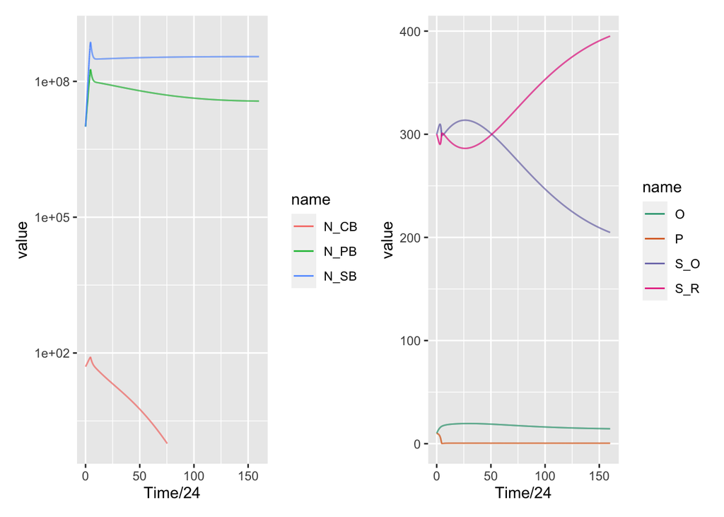

```r
colnames(run) <- c("Time", names(starting_densities))
run_longer <- run %>% pivot_longer(cols = -Time)
run_longer$group <- ifelse(run_longer$name %in% c("N_CB","N_PB","N_SB"),"Bacteria","Substrate")

run_longer %>%
  dplyr::filter(name %in% c("N_CB","N_PB","N_SB")) %>%
  ggplot(aes(Time/24,value,col=name)) +
  geom_line() +
  scale_y_log10(limits=c(10^0,10^9)) +

run_longer %>%
  dplyr::filter(name %in% c("S_O","S_R","O","P")) %>%
  ggplot(aes(Time/24,value,col=name)) +
  geom_line() +
  scale_color_brewer(palette = "Dark2")
```

The figure looks pretty identical! Only P looks different, but I used the starting value they stated, while in their figure they are using something else… successfully reproduced!

# 6 Stress testing: how long does it take?

For simplicity I just increase length of the simulations

```r
# 100 days, 2400 time steps per day
start_time <- Sys.time()
run <- ODEs_compiled(starting_densities,100*24,1/100)
end_time <- Sys.time()
paste("Running the model took", end_time-start_time, "seconds, not bad!")
```

```
## [1] "Running the model took 0.509974002838135 seconds, not bad!"
```

```r
# 500 days, 2400 time steps per day
start_time <- Sys.time()
run <- ODEs_compiled(starting_densities,500*24,1/100)
end_time <- Sys.time()
paste("Running the model took", end_time-start_time, "seconds, not bad!")
```

```
## [1] "Running the model took 2.5805869102478 seconds, not bad!"
```

```r
# 1000 days, 2400 time steps per day
start_time <- Sys.time()
run <- ODEs_compiled(starting_densities,1000*24,1/100)
end_time <- Sys.time()
paste("Running the model took", end_time-start_time, "seconds, not bad!")
```

```
## [1] "Running the model took 5.32967901229858 seconds, not bad!"
```

```r
# # 5000 days, 2400 time steps per day
# start_time <- Sys.time()
# run <- ODEs_compiled(starting_densities,5000*24,1/100)
# end_time <- Sys.time()
# paste("Running the model took", end_time-start_time, "seconds, not bad!")
#
# # 10000 days, 2400 time steps per day
# start_time <- Sys.time()
# run <- ODEs_compiled(starting_densities,10000*24,1/100)
# end_time <- Sys.time()
# paste("Running the model took", end_time-start_time, "seconds, not bad!")
```

# 7 Comparison with microxanox

Now let’s compare with microxanox. Let’s copy paste a bit of code from “partial-reproduction-Bushetal2017.Rmd” (i.e. the setup and stuff):

```r
library(tidyverse)
library(deSolve)
library(rootSolve)
library(here)
library(microxanox)
library(patchwork)
set.seed(13)
run_steadystate_sims <- FALSE
options(mc.cores=1) # let's just use 1 core for now!

ma <- rep(1e2, 3)
names(ma) <- c("CB", "PB", "SB")
parameter <- new_runsim_parameter(
  dynamic_model = bushplus_dynamic_model,
  strain_parameter = new_strain_parameter(),
  ## no default_initial_state
  sim_duration = 2000,
  sim_sample_interval = 1,
  log10a_series = c(
    log10(new_strain_parameter()$a_O),
    log10(new_strain_parameter()$a_O)
  ),
  event_definition = event_definition_1,
  event_interval = 10,
  noise_sigma = 0,
  minimum_abundances = ma
)

rm(ma)
# saveRDS(parameter, file = "data/partial_reproduction/parameter_default.RDS")
```

So here microxanox reproduces the figure 2a,b:

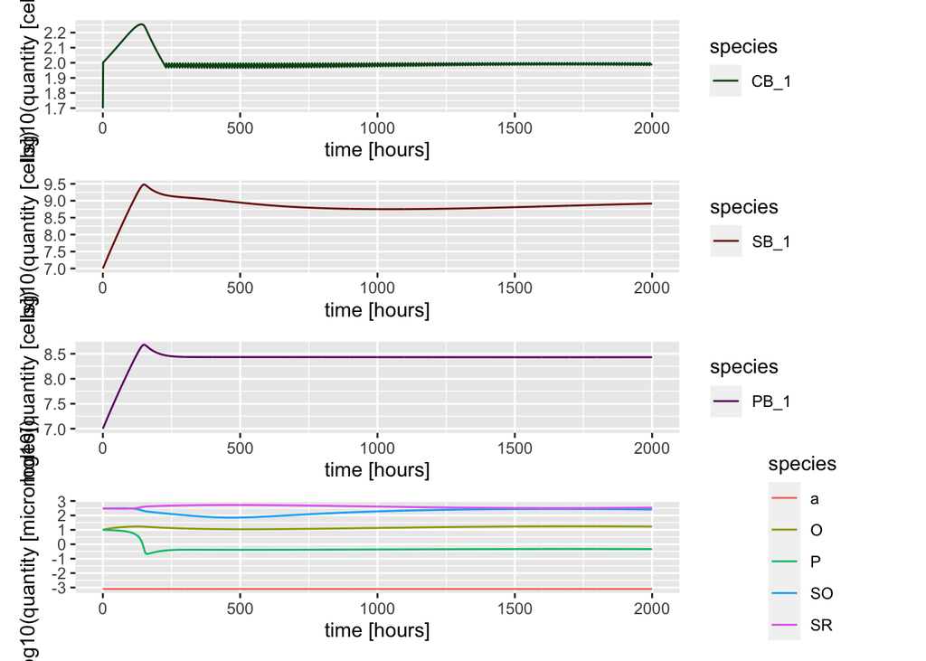

```r
parameter$strain_parameter$initial_state  <-  new_initial_state(values = "bush_anoxic_fig2ab")
sim_res <- run_simulation(parameter)
# saveRDS(sim_res, file = "data/partial_reproduction/bush_anoxic_fig2ab.RDS")

plot_dynamics(simulation_result = sim_res)
```

The parameters the microxanox used are here: (let’s compare them to the ones used above)

```r
sim_res$strain_parameter
```

```
## $CB
##   strain_name g_max_CB k_CB_P h_SR_CB   y_P_CB Pr_CB m_CB i_CB
## 1        CB_1     0.05    0.2     300 1.67e+08 6e-09 0.02    0
##
## $PB
##   strain_name g_max_PB k_PB_SR k_PB_P h_O_PB  y_SR_PB   y_P_PB  m_PB i_PB
## 1        PB_1     0.07      10    0.5    100 12500000 1.67e+08 0.028    0
##
## $SB
##   strain_name g_max_SB k_SB_SO k_SB_P h_O_SB  y_SO_SB   y_P_SB m_SB i_SB
## 1        SB_1      0.1       5    0.5    100 33300000 1.67e+08 0.04    0
##
## $a_S
## [1] 0.001
##
## $a_O
## [1] 8e-04
##
## $a_P
## [1] 0.01
##
## $back_SR
## [1] 300
##
## $back_SO
## [1] 300
##
## $back_O
## [1] 300
##
## $back_P
## [1] 9.5
##
## $c
## [1] 4e-05
##
## $initial_state
##  CB_1  PB_1  SB_1    SO    SR     O     P
## 5e+01 1e+07 1e+07 3e+02 3e+02 1e+01 1e+01
## attr(,"class")
## [1] "initial_state" "numeric"
##
## attr(,"class")
## [1] "strain_parameter" "list"
```

Parameter values and starting values are the same, as they should. Nice!

Ok now the interesting part: let’s compare!

Microxanox as above uses 2000 hours and 1 sample per hour as settings. We start with that.

## 7.1 2000 hours and 1 sample per hour

```r
microbenchmark(
  run_simulation(parameter), # microxanox
  ODEs_compiled(starting_densities,2000,1), # odeintr
  times = 10
)
```

```
## Unit: milliseconds
##                                        expr         min          lq        mean
##                   run_simulation(parameter) 6059.174845 6128.960899 6200.641351
##  ODEs_compiled(starting_densities, 2000, 1)    4.047299    4.061862    4.119331
##       median          uq         max neval
##  6203.169743 6244.519885 6364.313343    10
##     4.093454    4.136179    4.286611    10
```

Looks like odeintr is about 1000 times faster! But remember, ODEINTR must be compiled once, which takes some seconds.

Note: the resulting dataset differ quite a bit, so there must be a mistake somewhere…

```r
run1 <- run_simulation(parameter)
run1 <- run1$result
run2 <- ODEs_compiled(starting_densities,2000,1)
colnames(run2) <- c("Time", names(starting_densities))
merged  <- cbind(run1,run2)
print.data.frame(merged[1:40,])
```

```
##    time     CB_1     PB_1     SB_1       SO       SR        O         P
## 1     0  50.0000 10000000 10000000 300.0000 300.0000 10.00000 10.000000
## 2     1 100.4523 10310928 10461487 300.1420 299.8580 10.11131  9.987931
## 3     2 100.9071 10630852 10943288 300.2855 299.7145 10.22127  9.975770
## 4     3 101.3645 10960018 11446265 300.4302 299.5698 10.32989  9.963512
## 5     4 101.8246 11298682 11971314 300.5763 299.4237 10.43719  9.951151
## 6     5 102.2873 11647102 12519367 300.7237 299.2763 10.54319  9.938682
## 7     6 102.7526 12005544 13091395 300.8723 299.1277 10.64790  9.926100
## 8     7 103.2207 12374285 13688408 301.0221 298.9779 10.75135  9.913399
## 9     8 103.6914 12753603 14311459 301.1732 298.8268 10.85355  9.900573
## 10    9 104.1649 13143787 14961642 301.3253 298.6747 10.95452  9.887618
## 11   10 104.6411 13545135 15640097 301.4786 298.5214 11.05428  9.874526
## 12   11 105.1201 13957948 16348010 301.6330 298.3670 11.15285  9.861292
## 13   12 105.6019 14382539 17086614 301.7884 298.2116 11.25023  9.847909
## 14   13 106.0865 14819227 17857194 301.9447 298.0553 11.34645  9.834372
```

[output cut: 108 more lines]